# A Regression Example

Published

June 29, 2025

In this document we will use the data in **contraception.csv** to examine whether female education level explains variation in contraceptive useage after controlling for GNI.

```r
# Load libraries
library(tidyverse)
library(broom)
library(patchwork)

# Import data
contraception = read_csv("https://raw.githubusercontent.com/zief0002/symmetrical-fiesta/main/data/contraception.csv")

# View data
contraception
```

```
# A tibble: 97 × 5
   country                region                 contraceptive educ_female gni
   <chr>                  <chr>                          <dbl>       <dbl> <chr>
 1 Algeria                Middle East and North…            57         5.9 High
 2 Austria                Europe and Central As…            66         8.9 High
 3 Azerbaijan             Europe and Central As…            55        10.5 High
 4 Bangladesh             South Asia                        62         4.6 Low
 5 Belgium                Europe and Central As…            67        10.5 High
 6 Belize                 Latin America and the…            51         9.2 High
 7 Benin                  Sub-Saharan Africa                16         2   Low
 8 Bolivia                Latin America and the…            67         8.4 Low
 9 Bosnia and Herzegovina Europe and Central As…            46         7.2 High
10 Botswana               Sub-Saharan Africa                53         8.7 High
# ℹ 87 more rows
```

```r
# IF you want to see all the variables
#contraception |> print(width = Inf)
```

## Examine the Data

We need to correctly specify the model. Since we have no theory to guide us, this is done empirically by looking at the data.

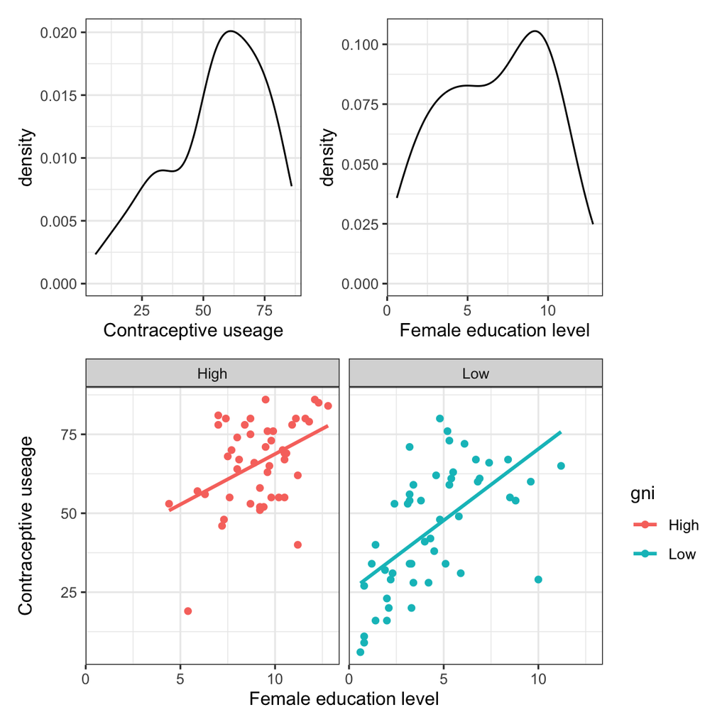

Figure 1: TOP-LEFT: Density plot of contracrptive useage. TOP-RIGHT: Density plot of female education level. BOTTOM: Scatterplot of contraceptive useage versus female education level conditioned on GNI.

```r
# Create density plot of contraception
p1 = ggplot(data = contraception, aes(x = contraceptive)) +
   geom_density() +
   theme_bw() +
   labs(
      x = "Contraceptive useage"
   )

# Create density plot of female education level
p2 = ggplot(data = contraception, aes(x = educ_female)) +
   geom_density() +
   theme_bw() +
   labs(
      x = "Female education level"
   )


# Condition the relationship on GNI
p3 = ggplot(data = contraception, aes(x = educ_female, y = contraceptive, color = gni)) +
   geom_point() +
   geom_smooth(method = "lm", se = FALSE) +
   theme_bw() +
   labs(
      x = "Female education level",
      y = "Contraceptive useage"
   ) +
   facet_wrap(~gni)

# Layout plots with patchwork
(p1 | p2) / p3
```

- Should we include main-effects only? Or an interaction?
- Is there non-linearity to account for (e.g., transformations)? Or does it look linear?

## Use Matrix Algebra to Compute Coefficient Estimates

$$\mathbf{b} = (\mathbf{X}^\intercal\mathbf{X})^{-1} \mathbf{X}^\intercal\mathbf{y}$$

```r
# Store values
n = nrow(contraception) #Sample size
k = 2 #Number of predictors


# Create outcome vector
y = contraception$contraceptive

# Create dummy variable for GNI
contraception = contraception %>%
   mutate(
      high_gni = if_else(gni == "High", 1, 0)
      )

# Create design matrix
X = matrix(
   data = c(rep(1, n), contraception$educ_female, contraception$high_gni),
   ncol = 3
)

# Compute b vector
b = solve(t(X) %*% X) %*% t(X) %*% y
b
```

```
          [,1]
[1,] 27.021387
[2,]  4.088735
[3,]  1.608766
```

Thus the fitted regression equation is:

$$\widehat{\mathrm{Contraceptive~Use}}_i = 27.02 + 4.09(\mathrm{Female~Education~Level}_i) + 1.60(\mathrm{High~GNI}_i)$$

## Compute Residual Standard Error

```r
# Compute e vector
e = y - X %*% b

# Compute s_e
s_e = sqrt((t(e) %*% e) / (n - k - 1))
s_e
```

```
         [,1]
[1,] 14.39792
```

Thus the residual standard error (a.k.a., the root mean square error; RMSE) is:

$$s_e = 14.40$$

## Compute Variance–Covariance Matrix for the Coefficients

$$\mathrm{Var}(\mathbf{b}) = s^2_e(\mathbf{X}^\intercal\mathbf{X})^{-1}$$

where $s^2_e = \frac{\mathbf{e}^\intercal\mathbf{e}}{n-k-1}$

```r
# Compute varaince-covariance matrix of b
V = as.numeric(s_e^2) * solve(t(X) %*% X)
V
```

```
          [,1]       [,2]      [,3]
[1,] 12.414688 -1.8783934  4.782603
[2,] -1.878393  0.4267136 -2.028306
[3,]  4.782603 -2.0283060 18.197825
```

```r
# Compute SEs for b
sqrt(diag(V))
```

```
[1] 3.5234483 0.6532332 4.2658909
```

Thus

$$\mathrm{SE}(b_0) = 3.52 \qquad \mathrm{SE}(b_1) = 0.65 \qquad \mathrm{SE}(b_2) = 4.27$$

## Coefficient-Level Inference

Here we will focus on the effects of female education level since it is our focal predictor. (GNI is a control.) Note this is the second effect in the **b** vector and in the **V** matrix. We will test the hypothesis:

$$H_0: \beta_{\mathrm{Education}} = 0$$

```r
# Compute t-value
t_0 = (b[2] - 0) / sqrt(V[2, 2])
t_0
```

```
[1] 6.259228
```

```r
# Evaluate t-value
df = n - k - 1
p = 2* (1 - pt(abs(t_0), df = df))
p
```

```
[1] 0.00000001143799
```

Here,

$$t(94) = 6.26,~p=0.0000000114$$

The evidence suggests that the data are not very compatible with the hypothesis that there is no effect of female education level on contraceptive useage, after controlling for differences in GNI.

## Statistical Inference: Confidence Intervals for the Coefficients

From the hypothesis test, we believe there is an effect of female education level on contraceptive useage, after controlling for differences in GNI. What is that effect? To answer this we will compute a 95% CI for the effect of female education.

```r
# Compute critical value
t_star = qt(.025, df = df)

# Compute CI
b[2] - abs(t_star) * sqrt(V[2, 2])
```

```
[1] 2.791725
```

```r
b[2] + abs(t_star) * sqrt(V[2, 2])
```

```
[1] 5.385745
```

The 95% CI indicates that the population effect of female education level on contraceptive useage, after controlling for differences in GNI is between 2.79 and 5.39.

# ANOVA Decompostion

Here we want to partition the sums of squares:

$$\mathrm{SS}_{\mathrm{Total}} = \mathrm{SS}_{\mathrm{Model}} + \mathrm{SS}_{\mathrm{Residual}}$$

```r
# Compute needed values
mean_y = mean(y)
hat_y = X %*% b


# Compute SS_Total
ss_total = t(y - mean_y) %*% (y - mean_y)
ss_total
```

```
         [,1]
[1,] 38336.45
```

```r
# Compute SS_model
ss_model = t(hat_y - mean_y) %*% (hat_y - mean_y)
ss_model
```

```
         [,1]
[1,] 18850.25
```

```r
# Compute SS_residual
ss_residual = t(y - hat_y) %*% (y - hat_y)
ss_residual
```

```
        [,1]
[1,] 19486.2
```

Here:

- $\mathrm{SS}_{\mathrm{Total}}=38,336.45$
- $\mathrm{SS}_{\mathrm{Model}}=18,850.25$
- $\mathrm{SS}_{\mathrm{Residual}}=19,486.2$

We can verify that:

$$38,336.45 = 18,850.25 + 19,486.2$$

This can be used to compute the model-level $R^2$ value.

$$R^2 = \frac{\mathrm{SS}_{\mathrm{Model}}}{\mathrm{SS}_{\mathrm{Total}}}$$

```r
# Compute R^2
r2 = ss_model / ss_total
r2
```

```
          [,1]
[1,] 0.4917057
```

The model explains 49.1% of the variation in contraception usage.

# Model-Level Inference

Here we want to test whether the model explained variation is more than we would expect because of sampling variation, namely

$$H_0: \rho^2=0$$

This is equivalent to testing:

$$H_0: \beta_{\mathrm{Female~Education}} = \beta_{\mathrm{GNI}} = 0$$

We compute an observed *F*-value as:

$$F_0 = \frac{(\mathbf{Lb}-\mathbf{c})^\intercal\big[\mathbf{L}(\mathbf{X}^\intercal\mathbf{X})^{-1}\mathbf{L}^\intercal\big]^{-1}(\mathbf{Lb}-\mathbf{c})}{q(s^2_e)}$$

```r
# Create L (hypothesis matrix)
L = matrix(
   data = c(0, 1, 0, 0, 0, 1),
   byrow = TRUE,
   ncol = 3
)

# Create vector of hypothesized values
C = matrix(
   data = c(0, 0),
   ncol = 1
)

q = 2

F_num = t(L %*% b - C) %*% solve(L %*% solve(t(X) %*% X) %*% t(L)) %*% (L %*% b - C)
F_denom = q * s_e^2

F_0 = F_num / F_denom
F_0
```

```
         [,1]
[1,] 45.46611
```

```r
# Evaluate F_0
1 - pf(F_0, df1 = q, df2 = (n - k - 1))
```

```
             [,1]
[1,] 1.532108e-14
```

Here,

$$F(2, 94) = 45.47,~p=0.0000000000000153$$

The data are not very compatible with the hypothesis that the model explains no variation in the outcome. It is likely there is a controlled effect of female education level, or GNI (or both) on contraceptive usage. That is, the explained variation of 49.1% is more than we would expect because of chance.

# In Practice

In practice, you would simply use built-in R functions to do all of this. Note that you can use a categorical variable in the `lm()` function directly (without dummy coding it beforehand), but it will pick the reference category for you (alphabetically). For example:

```r
# Fit model
lm.1 = lm(contraceptive ~ 1 + educ_female + gni, data = contraception)

# Coefficient-level output
tidy(lm.1)
```

```
# A tibble: 3 × 5
  term        estimate std.error statistic      p.value
  <chr>          <dbl>     <dbl>     <dbl>        <dbl>
1 (Intercept)    28.6      6.34      4.52  0.0000182
2 educ_female     4.09     0.653     6.26  0.0000000114
3 gniLow         -1.61     4.27     -0.377 0.707
```

```r
# Coempute confidence intervals for coefficients
confint(lm.1)
```

```
                 2.5 %    97.5 %
(Intercept)  16.044734 41.215571
educ_female   2.791725  5.385745
gniLow      -10.078792  6.861261
```

```r
# Model-level output
glance(lm.1)
```

```
# A tibble: 1 × 12
  r.squared adj.r.squared sigma statistic  p.value    df logLik   AIC   BIC
      <dbl>         <dbl> <dbl>     <dbl>    <dbl> <dbl>  <dbl> <dbl> <dbl>
1     0.492         0.481  14.4      45.5 1.54e-14     2  -395.  798.  808.
# ℹ 3 more variables: deviance <dbl>, df.residual <int>, nobs <int>
```

```r
# ANOVA decomposition
anova(lm.1)
```

```
Analysis of Variance Table

Response: contraceptive
            Df  Sum Sq Mean Sq F value   Pr(>F)
educ_female  1 18820.8 18820.8 90.7900 1.85e-15 ***
gni          1    29.5    29.5  0.1422   0.7069
Residuals   94 19486.2   207.3
---
Signif. codes:  0 '***' 0.001 '**' 0.01 '*' 0.05 '.' 0.1 ' ' 1
```

## Accessing Regression Matrices from lm()

There are several built-in R functions that allow you to access different regression matrices once you have fitted a model with `lm()`.

```r
# Access design matrix
model.matrix(lm.1)
```

```
   (Intercept) educ_female gniLow
1            1         5.9      0
2            1         8.9      0
3            1        10.5      0
4            1         4.6      1
:            :          :       :
97           1         6.7      1
attr(,"assign")
[1] 0 1 2
attr(,"contrasts")
attr(,"contrasts")$gni
[1] "contr.treatment"
```

The design matrix is given and information about this design matrix is also encoded. There is an attribute “assign”, an integer vector with an entry for each column in the matrix giving the term in the formula which gave rise to the column. Value 0 corresponds to the intercept (if any), and positive values to terms in the order given by the term.labels attribute of the terms structure corresponding to object. There is also an attribute called “contrasts” that identifies any factors (categorical variables) in the model and indicates how the contrast testing (comparison of the factor levels) will be carried out. Here “contr.treatment” is used. This compares each level of the factor to the baseline (which is how dummy coding works).

```r
# Access coefficient estimates
coef(lm.1)
```

```
(Intercept) educ_female      gniLow
  28.630153    4.088735   -1.608766
```

```r
# Access variance-covariance matrix for b
vcov(lm.1)
```

```
            (Intercept) educ_female     gniLow
(Intercept)   40.177719  -3.9066994 -22.980428
educ_female   -3.906699   0.4267136   2.028306
gniLow       -22.980428   2.0283060  18.197825
```

```r
# Access fitted values
fitted(lm.1)
```

```
       1        2        3        4        5        6        7        8
52.75369 65.01990 71.56187 45.82957 71.56187 66.24652 35.19886 61.36676
       9       10       11       12       13       14       15       16
58.06905 64.20215 71.97075 34.78998 36.01660 40.10534 47.87394 78.92160
      17       18       19       20       21       22       23       24
29.47463 67.88201 57.25130 35.60773 62.97553 71.56187 78.10385 60.11341
      25       26       27       28       29       30       31       32
58.88679 48.69168 51.96267 32.74562 73.19737 51.14493 69.10863 30.29238
      33       34       35       36       37       38       39       40
40.10534 48.69168 74.42399 40.10534 55.23366 46.62059 68.29089 68.69976
      41       42       43       44       45       46       47       48
74.42399 67.06427 70.33525 49.10056 74.01512 42.55858 59.70454 54.82479
      49       50       51       52       53       54       55       56
36.42548 46.64732 40.92309 66.24652 50.70932 32.74562 67.47314 61.34004
      57       58       59       60       61       62       63       64
61.74891 66.27325 61.77564 40.10534 30.29238 54.38919 36.83435 46.64732
      65       66       67       68       69       70       71       72
30.29238 44.19408 40.51421 67.88201 59.29567 63.00226 61.34004 71.15300
      73       74       75       76       77       78       79       80
39.69647 43.37633 40.92309 66.24652 35.19886 76.05948 76.87723 68.69976
      81       82       83       84       85       86       87       88
67.47314 58.47792 57.27803 67.90874 45.42070 57.25130 40.51421 49.50943
      89       90       91       92       93       94       95       96
44.60295 72.81522 80.96597 64.20215 64.20215 48.28281 31.92787 50.73605
      97
54.41591
```

```r
# Access raw residuals
resid(lm.1)
```

```
          1           2           3           4           5           6
  4.2463087   0.9801026 -16.5618739  16.1704304  -4.5618739 -15.2465180
          7           8           9          10          11          12
-19.1988577   5.6332361 -12.0690473 -11.2021503  -2.9707474  -2.7899842
         13          14          15          16          17          18
 -7.0166048  15.8946599 -13.8739373   6.0784025 -23.4746282   8.1179879
         19          20          21          22          23          24
 23.7486998 -15.6077312  15.0244703  -2.5618739   7.8961495   9.8865851
         25          26          27          28          29          30
 21.1132057  10.3083157  20.0373274   7.2543835   4.8026319 -20.1449256
         31          32          33          34          35          36
  6.8913673 -21.2923753  -6.1053401  24.3083157 -12.4239887  13.8946599
         37          38          39          40          41          42
  5.7663391   6.3794117  -3.2908856   4.3002408 -34.4239887 -15.0642650
         43          44          45          46          47          48
-15.3352533  11.8994421   5.9848849  11.4414187  -4.7045414   5.1752126
         49          50          51          52          53          54
 -5.4254783   1.3526833  18.0769128 -14.2465180 -31.7093236 -16.7456165
         55          56          57          58          59          60
 18.5268614   2.6599645   5.2510909  -6.2732463  -6.7756375  30.8946599
         61          62          63          64          65          66
 -3.2923753   1.6108145  16.1656482  33.3526833 -19.2923753 -16.1940755
         67          68          69          70          71          72
 -6.5142136  -4.8820121   8.7043321  -9.0022581  12.6599645  -1.1530004
         73          74          75          76          77          78
 13.3035334  -2.3763284 -12.9230872  -8.2465180 -12.1988577   3.9405172
         79          80          81          82          83          84
  2.1227701 -13.6997592   3.5268614 -10.4779208   8.7219714 -38.9087405
         85          86          87          88          89          90
 -7.4206961  20.7486998 -20.5142136  13.4905686  -2.6029490  -7.8152229
         91          92          93          94          95          96
  3.0340348  15.7978497  10.7978497  27.7171892   2.0721306  -1.7360520
         97
 12.5840862
```

**PROTIP**

The `tidy()` and `augment()` functions from the `{broom}` package also give the coefficients, residuals, and fitted values. The difference is in the type of out put you get. For example the residuals from `resid()` are outputted as a vector, whereas the residuals from `augment()` are outputted in a data frame/tibble. In R certain output types are better than other in different situations (e.g., `{ggplot2}` functions require data frames).